```r
library(data.table)
library(glmnet)
library(ggplot2)
library(lubridate, quietly=TRUE)
library(zoo, quietly = TRUE)
library(dplyr, quietly = TRUE)
library(GGally, quietly=TRUE)
library(caTools)
library(rpart)
library(rattle)
library(caret)
library(e1071)
library(randomForest)
library(gbm)
```

### Performance Function

```r
perf_dt=function(type,actual,forecast){
    name=type
    n=length(actual)
    error=actual-forecast
    mean=mean(actual)
    sd=sd(actual)
    FBias=sum(error)/sum(actual)
    MPE=sum(error/actual)/n
    MAPE=sum(abs(error/actual))/n
    RMSE=sqrt(sum(error^2))/n
    MAD=sum(abs(error))/n
    WMAPE=MAD/mean
    l=data.frame(name,n,mean,sd,FBias,MAPE,RMSE,MAD,WMAPE)
    return(l)
}
```

# Blog Comment Dataset

This data originates from blog posts. The raw HTML-documents of the blog posts were crawled and processed. The prediction task associated with the data is the prediction of the number of comments in the upcoming 24 hours. In order to simulate this situation, we choose a basetime (in the past) and select the blog posts that were published at most 72 hours before the selected base date/time. Then, we calculate all the features of the selected blog posts from the information that was available at the basetime, therefore each instance corresponds to a blog post. The target is the number of comments that the blog post received in the next 24 hours relative to the basetime.

In the train data, the basetimes were in the years 2010 and 2011. In the test data the basetimes were in February and March 2012. This simulates the real-world situtation in which training data from the past is available to predict events in the future.

The train data was generated from different basetimes that may temporally overlap. Therefore, if you simply split the train into disjoint partitions, the underlying time intervals may overlap. Therefore, the you should use the provided, temporally disjoint train and test splits in order to ensure that the evaluation is fair.

Attribute Information:

1...50: Average, standard deviation, min, max and median of the Attributes 51...60 for the source of the current blog post With source we mean the blog on which the post appeared. For example, myblog.blog.org would be the source of the post myblog.blog.org/post_2010_09_10 51: Total number of comments before basetime 52: Number of comments in the last 24 hours before the basetime 53: Let T1 denote the datetime 48 hours before basetime, Let T2 denote the datetime 24 hours before basetime. This attribute is the number of comments in the time period between T1 and T2 54: Number of comments in the first 24 hours after the publication of the blog post, but before basetime 55: The difference of Attribute 52 and Attribute 53 56...60: The same features as the attributes 51...55, but features 56...60 refer to the number of links (trackbacks), while features 51...55 refer to the number of comments. 61: The length of time between the publication of the blog post and basetime 62: The length of the blog post 63...262: The 200 bag of words features for 200 frequent words of the text of the blog post 263...269: binary indicator features (0 or 1) for the weekday (Monday...Sunday) of the basetime 270...276: binary indicator features (0 or 1) for the weekday (Monday...Sunday) of the date of publication of the blog post 277: Number of parent pages: we consider a blog post P as a parent of blog post B, if B is a reply (trackback) to blog post P. 278...280: Minimum, maximum, average number of comments that the parents received 281: The target: the number of comments in the next 24 hours (relative to basetime)

### Loading Dataset

```r
blog_data=read.csv("blogData_train.csv")
setnames(blog_data,"X1.0.2", "target")
```

```r
blog_data=as.data.table(blog_data)
blog_data=blog_data[0:10000]
blog_data=na.omit(blog_data)
str(blog_data)
```

```
Classes 'data.table' and 'data.frame':	10000 obs. of  281 variables:
 $ X40.30467   : num  40.3 40.3 40.3 40.3 40.3 ...
 $ X53.845657  : num  53.8 53.8 53.8 53.8 53.8 ...
 $ X0.0        : num  0 0 0 0 0 0 0 0 0 0 ...
 $ X401.0      : num  401 401 401 401 401 401 401 401 401 401 ...
 $ X15.0       : num  15 15 15 15 15 15 15 15 15 15 ...
 $ X15.52416   : num  15.5 15.5 15.5 15.5 15.5 ...
 $ X32.44188   : num  32.4 32.4 32.4 32.4 32.4 ...
 $ X0.0.1      : num  0 0 0 0 0 0 0 0 0 0 ...
 $ X377.0      : num  377 377 377 377 377 377 377 377 377 377 ...
 $ X3.0        : num  3 3 3 3 3 3 3 3 3 3 ...
 $ X14.044226  : num  14 14 14 14 14 ...
 $ X32.615417  : num  32.6 32.6 32.6 32.6 32.6 ...
 $ X0.0.2      : num  0 0 0 0 0 0 0 0 0 0 ...
 $ X377.0.1    : num  377 377 377 377 377 377 377 377 377 377 ...
```

[output cut: 87 more lines]

```r
set.seed(35)
spl=sample.split(blog_data$target, SplitRatio = 0.8)
blog_train=subset(blog_data,spl==TRUE)
blog_test=subset(blog_data,spl==FALSE)
```

## Penalized Regression Approaches(PRA)

### L1 Penalty with Mean Square Error measure

In order to tune lambda values, glmnet packages are used to get best lambda values for Penalized Regression.

```r
train_mat_blog=data.matrix(blog_train[complete.cases(blog_train),-c("target"),with=F])

result_vec_blog=as.vector(t(blog_train[complete.cases(blog_train),"target"]))

cvfit_blog=cv.glmnet(train_mat_blog,result_vec_blog,family="gaussian",nfolds = 10,type.measure = "mse")

test_mat_blog=data.matrix(blog_test[complete.cases(blog_test),-c("target")])

lasso_model_blog_mse_min <- glmnet(train_mat_blog,result_vec_blog, alpha = 1, lambda = cvfit_blog$lambda.min, standardize = FALSE)
lasso_model_blog_mse_1se <- glmnet(train_mat_blog,result_vec_blog, alpha = 1, lambda = cvfit_blog$lambda.1se, standardize = FALSE)
lasso_model_blog_mse_10th <- glmnet(train_mat_blog,result_vec_blog, alpha = 1, lambda = cvfit_blog$lambda[10], standardize = FALSE)
```

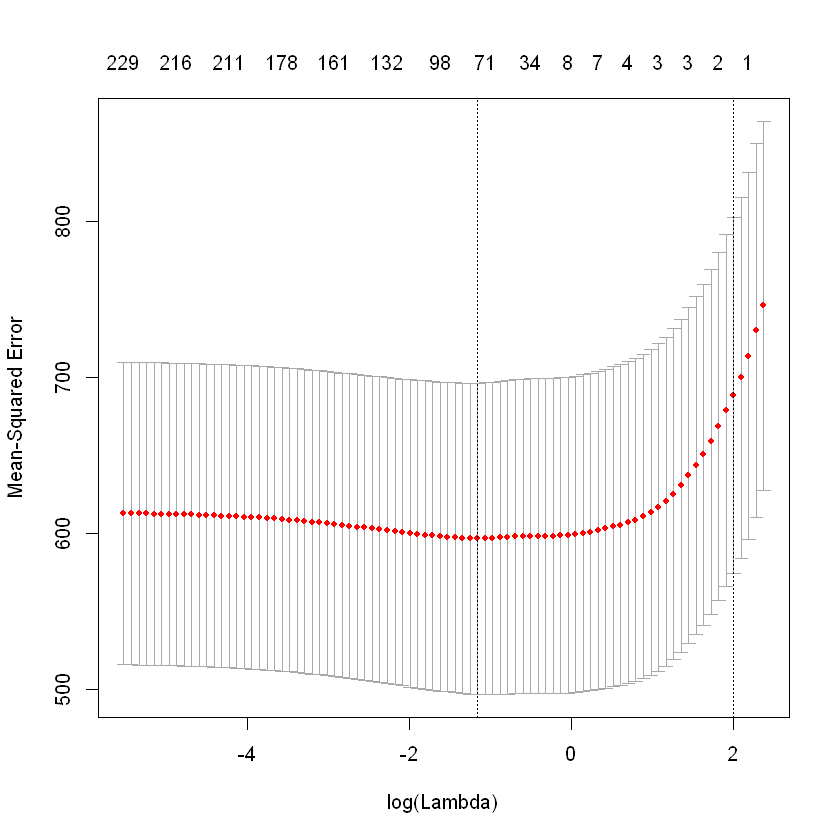

```r
plot(cvfit_blog)
```

### Lambda Values for Mean Square Error Values

```r
cvfit_blog$lambda.min
```

0.315280438601415

```r
cvfit_blog$lambda.1se
```

7.45477256891137

```r
cvfit_blog$lambda[10]
```

4.68181443856375

3 possible lambda values are determined by the cv.glmnet(). One of them is used for getting minimum Mean-Squared Error. The other one is determined by package by looking how many paramater is used in the model. Namely, this lambda value can be beneficial for reducing the possibility of over-fitting model on train dataset. Lastly, one random lambda was selected to compare results for these 3 lambda values.

```r
prediction_pra_mse_blog_min <- predict(lasso_model_blog_mse_min, s = cvfit_blog$lambda.min, newx = test_mat_blog)
prediction_pra_mse_blog_1se <- predict(lasso_model_blog_mse_1se, s = cvfit_blog$lambda.1se, newx = test_mat_blog)
prediction_pra_mse_blog_10th <- predict(lasso_model_blog_mse_10th, s = cvfit_blog$lambda[10], newx = test_mat_blog)
```

## L1 Penalty with Mean Absolute Error measure

```r
train_mat_blog=data.matrix(blog_train[complete.cases(blog_train),-c("target"),with=F])

result_vec_blog=as.vector(t(blog_train[complete.cases(blog_train),"target"]))

cvfit_blog_mae=cv.glmnet(train_mat_blog,result_vec_blog,family="gaussian",nfolds = 10,type.measure = "mae")

test_mat_blog=data.matrix(blog_test[complete.cases(blog_test),-c("target")])

lasso_model_blog_mae_min <- glmnet(train_mat_blog,result_vec_blog, alpha = 1, lambda = cvfit_blog_mae$lambda.min, standardize = FALSE)
lasso_model_blog_mae_1se <- glmnet(train_mat_blog,result_vec_blog, alpha = 1, lambda = cvfit_blog_mae$lambda.1se, standardize = FALSE)
lasso_model_blog_mae_10th <- glmnet(train_mat_blog,result_vec_blog, alpha = 1, lambda = cvfit_blog_mae$lambda[10], standardize = FALSE)
```

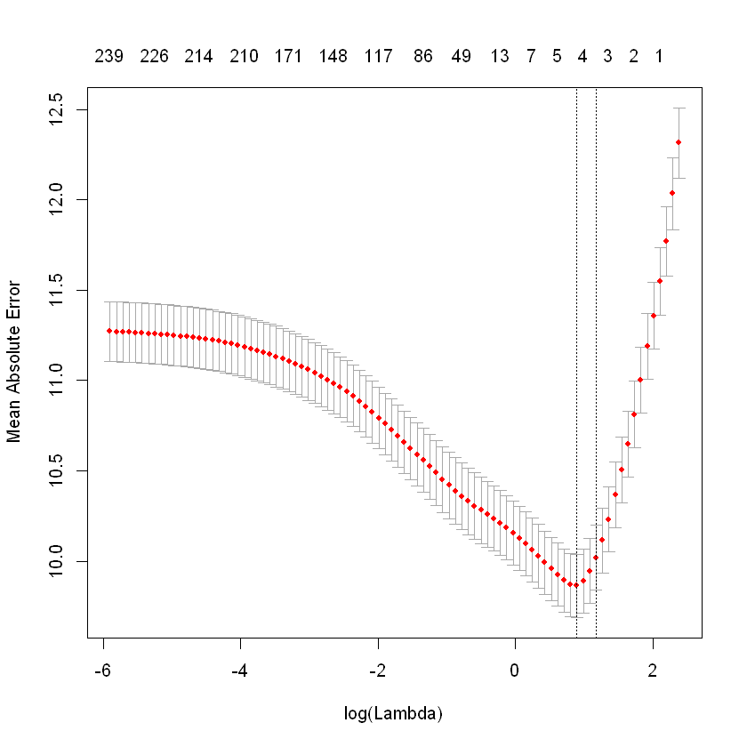

```r
plot(cvfit_blog_mae)
```

```r
cvfit_blog_mae$lambda.min
```

2.44110193003535

```r
cvfit_blog_mae$lambda.1se
```

3.22699308807477

```r
cvfit_blog_mae$lambda[10]
```

4.68181443856375

```r
prediction_pra_mae_blog_min <- predict(lasso_model_blog_mae_min, s = cvfit_blog_mae$lambda.min, newx = test_mat_blog)
prediction_pra_mae_blog_1se <- predict(lasso_model_blog_mae_1se, s = cvfit_blog_mae$lambda.1se, newx = test_mat_blog)
prediction_pra_mae_blog_10th <- predict(lasso_model_blog_mae_10th, s = cvfit_blog_mae$lambda[10], newx = test_mat_blog)
```

### Performance Measure for Lasso Regression

```r
perf_dt("Blog Data Set for Lasso Function with min lambda and mse objective", as.numeric(blog_test$target), prediction_pra_mse_blog_min)
perf_dt("Blog Data Set for Lasso Function with 1se lambda and mse objective", as.numeric(blog_test$target), prediction_pra_mse_blog_1se)
perf_dt("Blog Data Set for Lasso Function with 10th lambda and mse objective", as.numeric(blog_test$target), prediction_pra_mse_blog_10th)

perf_dt("Blog Data Set for Lasso Function with min lambda and mae objective", as.numeric(blog_test$target), prediction_pra_mae_blog_min)
perf_dt("Blog Data Set for Lasso Function with 1se lambda and mae objective", as.numeric(blog_test$target), prediction_pra_mae_blog_1se)
perf_dt("Blog Data Set for Lasso Function with 10th lambda and mae objective", as.numeric(blog_test$target), prediction_pra_mae_blog_10th)
```

| name | n | mean | sd | FBias | MAPE | RMSE | MAD | WMAPE |
| --- | --- | --- | --- | --- | --- | --- | --- | --- |
| Blog Data Set for Lasso Function with min lambda and mse objective | 1977 | 7.152757 | 16.66787 | -0.2243988 | Inf | 0.3313882 | 8.906574 | 1.245195 |

| name | n | mean | sd | FBias | MAPE | RMSE | MAD | WMAPE |
| --- | --- | --- | --- | --- | --- | --- | --- | --- |
| Blog Data Set for Lasso Function with 1se lambda and mse objective | 1977 | 7.152757 | 16.66787 | -0.2301968 | Inf | 0.3298626 | 8.726155 | 1.219971 |

| name | n | mean | sd | FBias | MAPE | RMSE | MAD | WMAPE |
| --- | --- | --- | --- | --- | --- | --- | --- | --- |
| Blog Data Set for Lasso Function with 10th lambda and mse objective | 1977 | 7.152757 | 16.66787 | -0.2276585 | Inf | 0.33034 | 8.790585 | 1.228979 |

| name | n | mean | sd | FBias | MAPE | RMSE | MAD | WMAPE |
| --- | --- | --- | --- | --- | --- | --- | --- | --- |
| Blog Data Set for Lasso Function with min lambda and mae objective | 1977 | 7.152757 | 16.66787 | -0.2257989 | Inf | 0.3308737 | 8.852091 | 1.237578 |

| name | n | mean | sd | FBias | MAPE | RMSE | MAD | WMAPE |
| --- | --- | --- | --- | --- | --- | --- | --- | --- |
| Blog Data Set for Lasso Function with 1se lambda and mae objective | 1977 | 7.152757 | 16.66787 | -0.2264184 | Inf | 0.3306597 | 8.827931 | 1.2342 |

| name | n | mean | sd | FBias | MAPE | RMSE | MAD | WMAPE |
| --- | --- | --- | --- | --- | --- | --- | --- | --- |
| Blog Data Set for Lasso Function with 10th lambda and mae objective | 1977 | 7.152757 | 16.66787 | -0.2276585 | Inf | 0.33034 | 8.790585 | 1.228979 |

### Glmnet with Caret Library

```r
fitControl=trainControl(method = "repeatedcv",
                           number = 10)
```

In order to compare obtained result with resamples function, the same process will be made with caret() library.

```r
lambda_grid <- expand.grid(alpha = 1, lambda = c(cvfit_blog_mae$lambda.min,
                                                 cvfit_blog_mae$lambda.1se,
                                                 cvfit_blog_mae$lambda[10]))
```

```r
lm_model <- train(target ~ ., data = blog_train, method = "glmnet",
                   trControl = fitControl, tuneGrid = lambda_grid)
```

```
glmnet

8023 samples
 280 predictor

No pre-processing
Resampling: Cross-Validated (10 fold, repeated 1 times)
Summary of sample sizes: 7221, 7220, 7220, 7220, 7222, 7220, ...
Resampling results across tuning parameters:

  lambda    RMSE      Rsquared   MAE
  2.441102  24.42847  0.2050926   9.869664
  3.226993  24.61889  0.2009448  10.022668
  4.681814  25.07599  0.1863053  10.510031

Tuning parameter 'alpha' was held constant at a value of 1
RMSE was used to select the optimal model using the smallest value.
The final values used for the model were alpha = 1 and lambda = 2.441102.
```

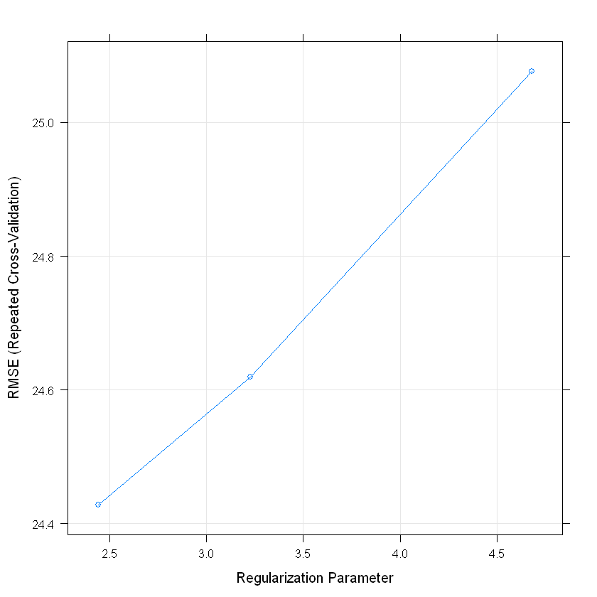

```r
lm_model
plot(lm_model)
```

## Decision Tree(DT)

```r
set.seed(35)
```

```
CART

8023 samples
 280 predictor

No pre-processing
Resampling: Cross-Validated (10 fold, repeated 1 times)
Summary of sample sizes: 7222, 7220, 7221, 7220, 7220, 7221, ...
Resampling results across tuning parameters:

  cp    RMSE      Rsquared   MAE
  0.00  22.19199  0.3853273   7.603728
  0.01  23.39357  0.2852710   8.856399
  0.02  23.45041  0.2620904   9.370173
  0.03  23.47057  0.2560673   9.483803
  0.04  24.00953  0.2217356   9.657709
  0.05  24.46023  0.1884401   9.994240
  0.06  24.72126  0.1710733  10.129938
  0.07  25.31053  0.1284348  10.426885
  0.08  25.29362  0.1299611  10.451589
  0.09  25.29362  0.1299611  10.451589
  0.10  25.29362  0.1299611  10.451589

RMSE was used to select the optimal model using the smallest value.
The final value used for the model was cp = 0.
CART

8023 samples
 280 predictor

No pre-processing
Resampling: Cross-Validated (10 fold, repeated 1 times)
Summary of sample sizes: 7222, 7220, 7220, 7221, 7221, 7221, ...
Resampling results across tuning parameters:

  cp    RMSE      Rsquared   MAE
  0.00  22.11942  0.3767113   7.753684
  0.01  23.11049  0.2882539   8.865858
  0.02  23.29740  0.2702750   9.287989
  0.03  23.63279  0.2461694   9.460335
  0.04  24.01674  0.2152860   9.615323
  0.05  24.60202  0.1785025   9.990932
  0.06  24.77930  0.1660326  10.153959
  0.07  25.22729  0.1323202  10.359830
  0.08  25.29586  0.1285914  10.409245
  0.09  25.29586  0.1285914  10.409245
  0.10  25.29586  0.1285914  10.409245

RMSE was used to select the optimal model using the smallest value.
The final value used for the model was cp = 0.
```

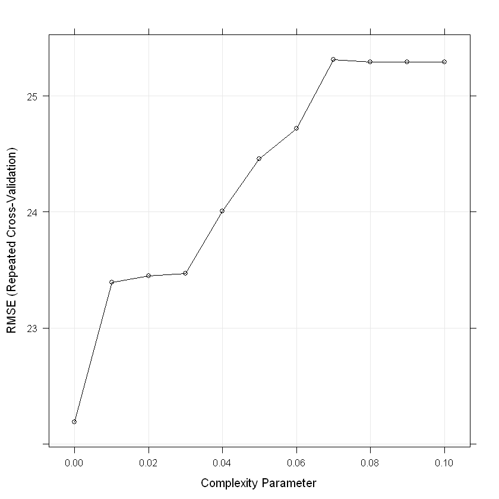

```
CART

8023 samples
 280 predictor

No pre-processing
Resampling: Cross-Validated (10 fold, repeated 1 times)
Summary of sample sizes: 7220, 7220, 7220, 7221, 7221, 7221, ...
Resampling results across tuning parameters:

  cp    RMSE      Rsquared   MAE
  0.00  22.41309  0.3566943   7.826263
  0.01  23.17618  0.2900864   8.809889
  0.02  23.37807  0.2760738   9.219326
  0.03  23.58675  0.2577259   9.431677
  0.04  23.95065  0.2335036   9.506912
  0.05  24.37008  0.2006009   9.834922
  0.06  25.19986  0.1465266  10.291834
  0.07  25.46280  0.1255471  10.445302
  0.08  25.46280  0.1255471  10.445302
  0.09  25.46280  0.1255471  10.445302
  0.10  25.46280  0.1255471  10.445302

RMSE was used to select the optimal model using the smallest value.
The final value used for the model was cp = 0.
```

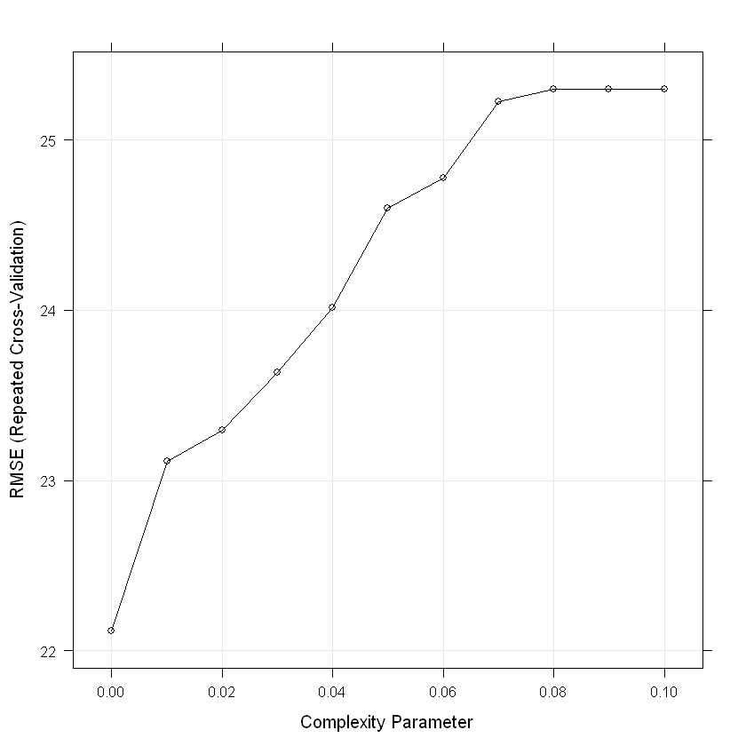

```
CART

8023 samples
 280 predictor

No pre-processing
Resampling: Cross-Validated (10 fold, repeated 1 times)
Summary of sample sizes: 7221, 7221, 7221, 7221, 7220, 7220, ...
Resampling results across tuning parameters:

  cp    RMSE      Rsquared   MAE
  0.00  22.34826  0.3582948   7.950214
  0.01  23.22672  0.2871459   8.802480
  0.02  23.37998  0.2721888   9.315961
  0.03  23.33501  0.2758044   9.383709
  0.04  24.23808  0.2120166   9.702696
  0.05  24.32628  0.2002152   9.935582
  0.06  24.65797  0.1802512  10.049736
  0.07  25.31352  0.1309855  10.337748
  0.08  25.29457  0.1316937  10.404182
  0.09  25.29457  0.1316937  10.404182
  0.10  25.29457  0.1316937  10.404182

RMSE was used to select the optimal model using the smallest value.
The final value used for the model was cp = 0.
```

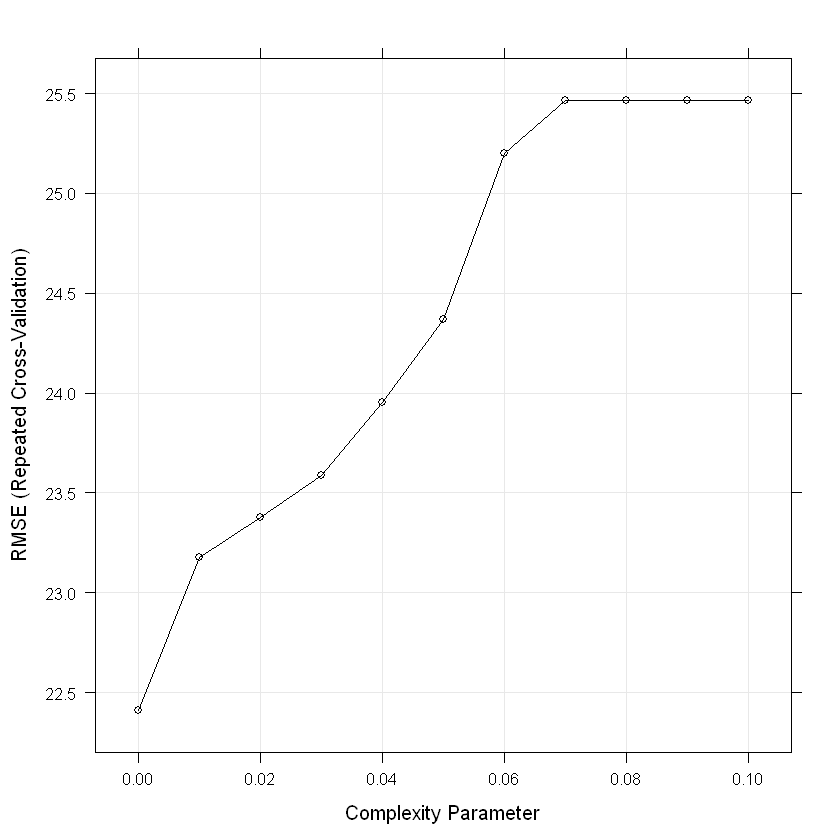

```
CART

8023 samples
 280 predictor

No pre-processing
Resampling: Cross-Validated (10 fold, repeated 1 times)
Summary of sample sizes: 7221, 7221, 7221, 7222, 7221, 7220, ...
Resampling results across tuning parameters:

  cp    RMSE      Rsquared   MAE
  0.00  22.05051  0.3740397   7.943829
  0.01  23.35699  0.2840902   8.843194
  0.02  23.65451  0.2583118   9.267911
  0.03  23.61097  0.2554079   9.405995
  0.04  24.23950  0.2144014   9.628656
  0.05  24.68917  0.1821829   9.980277
  0.06  25.08616  0.1558009  10.162702
  0.07  25.49545  0.1259631  10.325817
  0.08  25.53129  0.1246686  10.415070
  0.09  25.53129  0.1246686  10.415070
  0.10  25.53129  0.1246686  10.415070

RMSE was used to select the optimal model using the smallest value.
The final value used for the model was cp = 0.
```

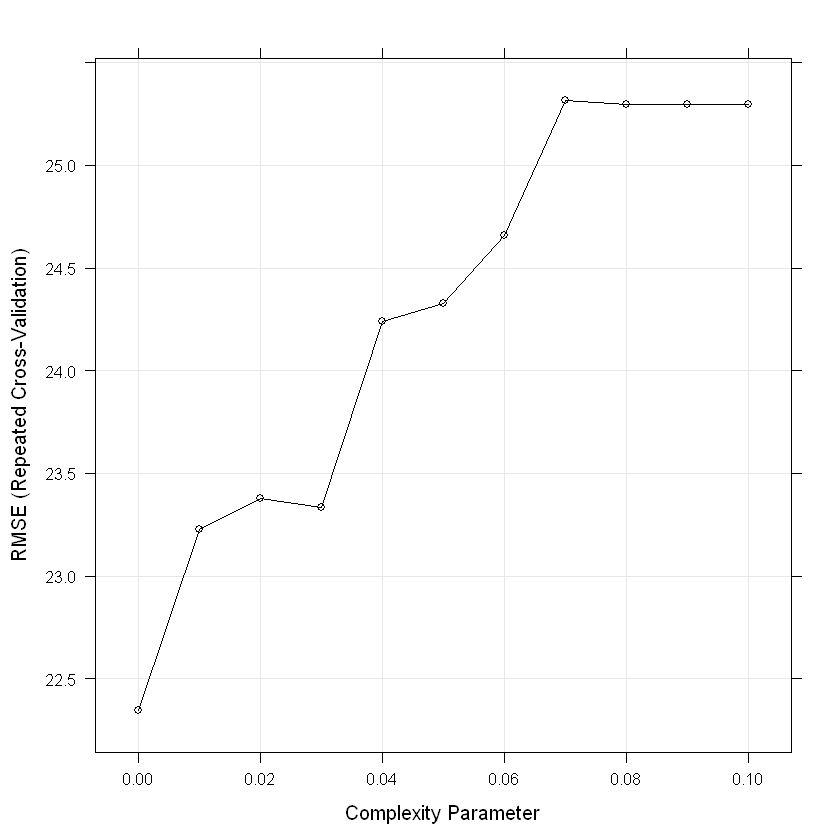

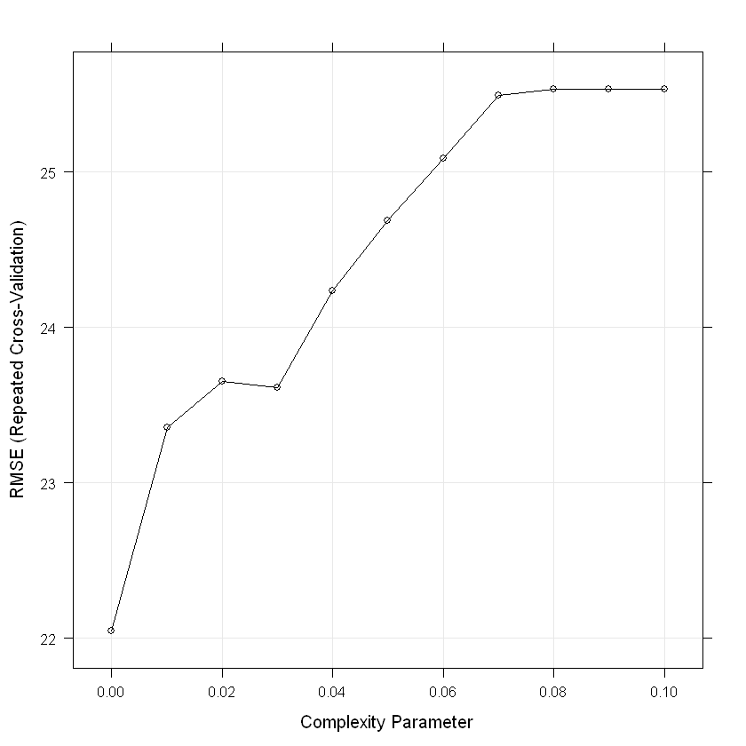

```
CART

8023 samples
 280 predictor

No pre-processing
Resampling: Cross-Validated (10 fold, repeated 1 times)
Summary of sample sizes: 7220, 7221, 7221, 7221, 7221, 7220, ...
Resampling results across tuning parameters:

  cp    RMSE      Rsquared   MAE
  0.00  22.40235  0.3457160   7.854748
  0.01  23.44146  0.2726905   8.791024
  0.02  23.52858  0.2594959   9.278822
  0.03  23.59981  0.2496713   9.394675
  0.04  24.12738  0.2171165   9.574562
  0.05  24.41028  0.1974758   9.940318
  0.06  24.85231  0.1673103  10.049114
  0.07  25.28040  0.1341191  10.321568
  0.08  25.38610  0.1280509  10.411522
  0.09  25.38610  0.1280509  10.411522
  0.10  25.38610  0.1280509  10.411522

RMSE was used to select the optimal model using the smallest value.
The final value used for the model was cp = 0.
```

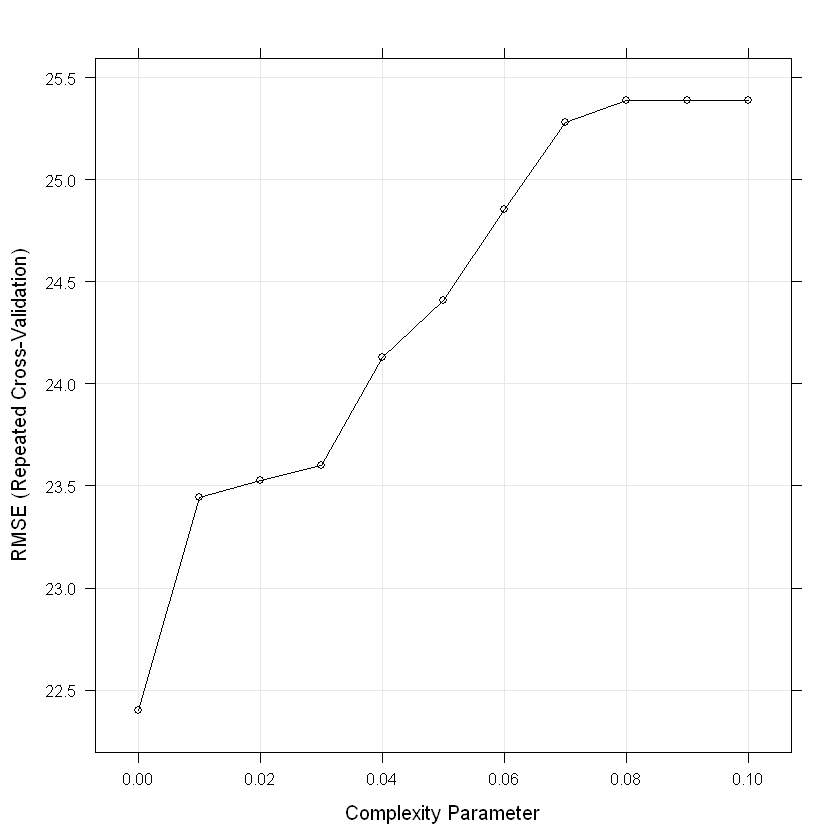

```r
cpGrid=expand.grid(.cp=(0:10)*0.01)
for(i in 5:10){
    tr=train(target~.,
          data=blog_train,
          method="rpart",
          trControl=fitControl,
          tuneGrid= cpGrid,
            # minbucket=minbucket_grid
           control= rpart.control(minbucket = i)
            )
    trellis.par.set(caretTheme())
    print(plot(tr))
    print(tr)
}
```

```
CART

8023 samples
 280 predictor

No pre-processing
Resampling: Cross-Validated (10 fold, repeated 1 times)
Summary of sample sizes: 7220, 7220, 7221, 7222, 7221, 7220, ...
Resampling results across tuning parameters:

  cp    RMSE      Rsquared   MAE
  0.00  22.57559  0.3897072   7.384471
  0.01  23.31100  0.2881720   8.693458
  0.02  23.59941  0.2619470   9.289978
  0.03  23.57051  0.2572654   9.434858
  0.04  24.22841  0.2119279   9.718694
  0.05  24.51101  0.1872444   9.984797
  0.06  24.51033  0.1872444   9.990837
  0.07  25.27038  0.1352021  10.349000
  0.08  25.27885  0.1329492  10.415419
  0.09  25.27885  0.1329492  10.415419
  0.10  25.27885  0.1329492  10.415419

RMSE was used to select the optimal model using the smallest value.
The final value used for the model was cp = 0.
```

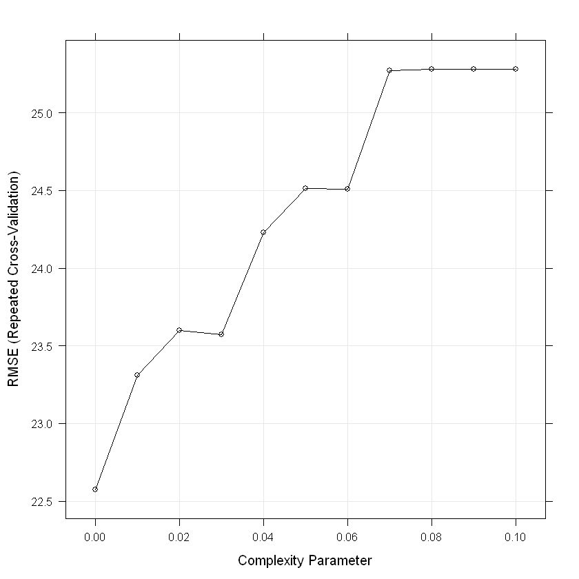

```r
cpGrid=expand.grid(.cp=(0:10)*0.01)
tr_last=train(target~.,
      data=blog_train,
      method="rpart",
      trControl=fitControl,
      tuneGrid= cpGrid,
       control= rpart.control(minsplit = 8)
        )
trellis.par.set(caretTheme())
print(plot(tr_last))
print(tr_last)
```

**X2.0.4**

1550799.0666189

**X2.0.2**

1403887.12460683

**X10.0.1**

1127240.16411385

**X2.0.3**

880771.788474947

**X2.0.1**

876731.467600778

**X401.0**

440618.41686825

**X0.0.20**

436372.558790126

**X15.52416**

425300.120859836

**X32.44188**

408365.438295677

**X15.0**

390821.826720942

**X377.0**

366181.799733973

**X14.044226**

239648.670705663

**X53.845657**

213377.855323924

**X40.30467**

148981.427286889

**X0.0.14**

147648.00989148

**X3.0**

118731.482443682

**X0.0.152**

106276.114202429

**X.356.0**

97728.7770190944

**X0.0.129**

91922.7155359656

**X0.0.27**

90876.3522179959

**X0.0.25**

90331.219717784

**X0.0.165**

85855.0490449291

**X2.0**

79046.8366475724

**X0.0.80**

70019.7810859589

**X0.0.37**

68449.4428161693

**X0.0.101**

67964.3193290515

**X0.0.204**

62257.3792021872

**X1.0.1**

61718.6103827174

**X48.475178**

58040.7839995776

**X0.0.224**

58033.8733586402

**X0.0.86**

57728.2553326026

**X0.0.206**

54360.6714972462

**X0.0.142**

53276.0074911939

**X1.4799345**

52289.3075518091

**X0.0.30**

51299.5738374768

**X12.0**

50606.1787154529

**X11.0**

50605.8768835918

**X0.0.184**

49284.9282485391

**X0.0.59**

46563.9746823896

**X1.795416**

45664.9476638345

**X1.0761671**

45579.9039496775

**X0.0.227**

44111.6297508718

**X0.0.97**

42830.1638358179

**X0.0.191**

42425.0665624955

**X0.0.221**

41170.3753300316

**X0.0.232**

41131.0379495019

**X0.0.223**

40849.2488425584

**X0.0.109**

40604.6090284088

**X0.0.190**

35836.8174539349

**X0.0.230**

35731.3219670888

**X0.0.225**

35204.1698120411

**X0.0.226**

32954.0373584804

**X0.0.111**

32923.9358879276

**X0.0.60**

32710.877100889

**X0.0.19**

31334.5010604255

**X0.0.228**

29269.3884449824

**X0.0.93**

27752.6692045797

**X0.0.139**

27686.6790463771

**X0.0.62**

26119.3419782839

**X0.0.222**

25766.1697257449

**X0.0.215**

25191.2481185726

**X0.0.16**

24407.7427889585

**X0.0.231**

24301.1084267886

**X0.0.171**

24264.4063000058

**X0.0.117**

22400.0921743446

**X0.0.72**

21874.380021863

**X0.0.229**

21867.6633402137

**X0.0.98**

21819.5503648526

**X0.0.54**

21527.0699580708

**X0.0.78**

18685.7603716802

**X0.0.160**

18284.8098545673

**X0.0.77**

18166.0351301143

**X0.0.35**

18048.2041176031

**X0.0.128**

17731.8805620435

**X0.0.94**

17678.9461308468

**X0.0.40**

17292.4329420144

**X0.0.186**

17112.9073596909

**X0.0.112**

15910.9846108527

**X0.0.61**

15845.3510386777

**X0.0.138**

14577.8773513397

**X0.0.26**

14054.5966053094

**X0.0.99**

13986.488830587

**X0.0.44**

13697.8521830575

**X0.0.210**

13487.4038871755

**X0.0.79**

13069.5059005671

**X0.0.22**

12590.3283232375

**X0.0.151**

12349.8172993564

**X34.567566**

12245.1238245234

**X0.0.168**

12178.9451820688

**X0.0.63**

11549.6132081696

**X0.0.33**

11353.1900736397

**X0.0.153**

10706.6910246547

**X0.0.116**

10076.1027074348

**X0.0.203**

9697.75179984727

**X0.972973**

9616.37363286485

**X0.0.213**

9289.33254842854

**X0.0.199**

9181.30773805277

**X0.0.141**

9055.68970327044

**X0.0.74**

9030.33093140889

**X0.0.92**

8870.68711839842

**X0.0.133**

8847.92477769235

**X0.0.132**

8572.78891679579

**X0.0.145**

7534.48750378331

**X0.0.15**

7459.15532938928

**X0.0.192**

6955.03529989613

**X0.0.4**

6814.3200788503

**X10.0**

6647.35089977182

**X0.0.174**

6632.45144385036

**X9.0**

6467.41261412556

**X0.0.188**

6248.31256377371

**X0.0.68**

6022.75907416396

**X1.0**

5928.96486678299

**X0.0.73**

5877.87483260942

**X0.0.95**

5669.60270979826

**X0.0.179**

5668.78956415783

**X0.0.46**

5580.11532846664

**X0.0.118**

5154.79787361404

**X0.0.18**

5100.93212732662

**X0.0.150**

5090.0425653575

**X0.0.28**

5087.32654438295

**X0.0.205**

4974.98973620073

**X9.0.1**

4681.73373646587

**X9.0.2**

4678.86715952017

**X0.0.83**

4602.95240911184

**X0.0.85**

4466.38137491122

**X0.0.105**

4190.25999951042

**X0.0.155**

4113.77671728251

**X0.0.115**

3990.59826999363

**X0.0.121**

3961.89259905475

**X0.0.180**

3860.92273616346

**X0.0.233**

3635.30695862142

**X0.0.108**

2948.20947094655

**X0.0.144**

2942.76904228381

**X0.0.17**

2878.13127272584

**X0.0.58**

2748.41172699025

**X0.0.96**

2722.10590372938

**X0.0.66**

2691.44255568894

**X0.0.89**

2539.26144009406

**X0.0.149**

2492.98812174511

**X0.0.159**

2473.93736078386

**X1.0780969**

2383.44715867138

**X0.0.47**

2289.49775231311

**X0.0.50**

2282.02008228368

**X0.0.134**

2030.40293261436

**X.8.0**

1961.30101359826

**X0.4004914**

1950.68552584772

**X0.0.209**

1927.75303607408

**X0.0.57**

1911.81451908739

**X0.0.169**

1715.78323241791

**X0.0.120**

1706.53109297982

**X0.0.198**

1698.24513953976

**X0.0.32**

1679.57990571486

**X1.704671**

1582.77624883548

**X0.0.146**

1402.34625027069

**X0.0.135**

1402.21125730994

**X0.0**

1247.57533107894

**X1.07421**

1149.27251267664

**X0.0.185**

1119.74725318851

**X0.0.3**

1024.014652105

**X32.615417**

992.497583607594

**X0.0.29**

987.747016421972

**X0.0.51**

984.990774628478

**X0.0.236**

955.039659800918

**X0.0.166**

951.923199642419

**X0.0.56**

927.570553784681

**X377.0.1**

878.616233260432

**X46.18691**

875.7953567817

**X378.0**

863.937289481663

**X0.0.200**

833.015135288457

**X0.0.189**

767.40325630551

**X0.37755936**

750.140183281844

**X0.0.235**

729.928364126108

**X0.0.75**

714.500906996252

**X0.0.122**

689.548432235332

**X0.0.176**

639.108743509585

**X0.0.103**

526.644124251172

**X0.0.154**

425.609268001655

**X0.0.195**

396.66787666286

**X0.0.65**

383.406445869073

**X0.0.207**

361.133576068066

**X0.0.177**

342.498394017047

**X0.0.76**

305.427499442163

**X0.0.147**

301.00149717767

**X0.0.187**

258.307956252236

**X0.0.167**

205.671477000896

**X0.0.193**

168.414325303102

**X0.0.196**

121.559295415452

**X0.0.41**

90.9061288233836

**X0.022932023**

82.6750566803229

**X0.0.21**

79.9926640505777

**X0.0.163**

76.6885986604813

**X0.0.49**

74.5888078415396

**X0.0.6**

71.9691808856715

**X0.0.126**

66.9496820448846

**X0.0.182**

55.0037814263842

**X0.0.173**

38.1113183958821

**X0.0.23**

37.8190202245351

**X0.0.24**

37.8190202245351

**X0.0.31**

37.8190202245351

**X0.0.100**

36.2535297386028

**X0.0.36**

34.2337459892879

**X0.0.34**

33.4748410224423

**X0.0.212**

21.5089092585624

**X0.0.84**

13.4541004894615

**X0.0.104**

9.87830687830689

**X0.0.216**

9.59463359463361

**X0.0.217**

5.16632940702708

**X0.0.102**

3.31515812431846

**X0.0.123**

3.12597574347723

**X0.0.45**

3.01474288577238

**X0.0.164**

1.67731579656181

**X0.0.125**

0.976362308456898

**X0.0.178**

0.870748299319727

**X0.0.183**

0.139325782409416

[figure not shown]

```r
reg_tree_blog=tr_last$finalModel
fancyRpartPlot(reg_tree_blog)
reg_tree_blog$variable.importance
```

```r
predicted_blog_dt=predict(reg_tree_blog,newdata=blog_test)
```

### Performanca Measure

```r
perf_dt("Decision Tree with CV for Blog Comment Dataset",blog_test$target,as.numeric(predicted_blog_dt))
```

| name | n | mean | sd | FBias | MAPE | RMSE | MAD | WMAPE |
| --- | --- | --- | --- | --- | --- | --- | --- | --- |
| Decision Tree with CV for Blog Comment Dataset | 1977 | 7.152757 | 16.66787 | -0.211185 | NaN | 0.3807407 | 6.082319 | 0.8503462 |

## Random Forest(RF)

```r
library(ranger)
```

```r
rf_grid=expand.grid(mtry=c(4,8,10,15),
                   splitrule = c("variance"),
                   min.node.size= c(5))
rf_grid
```

| mtry | splitrule | min.node.size |
| --- | --- | --- |
| 4 | variance | 5 |
| 8 | variance | 5 |
| 10 | variance | 5 |
| 15 | variance | 5 |

```r
rf_fit=train(target ~ ., data = blog_train,
                 method = "ranger",
                 trControl = fitControl, num.trees=500,
                 tuneGrid = rf_grid)
```

```
Random Forest

8023 samples
 280 predictor

No pre-processing
Resampling: Cross-Validated (10 fold, repeated 1 times)
Summary of sample sizes: 7220, 7221, 7220, 7221, 7221, 7221, ...
Resampling results across tuning parameters:

  mtry  RMSE      Rsquared   MAE
   4    23.12233  0.3410507  9.550554
   8    20.40609  0.4818724  7.921203
  10    19.78936  0.5023333  7.523441
  15    19.20015  0.5178478  6.988483

Tuning parameter 'splitrule' was held constant at a value of variance

Tuning parameter 'min.node.size' was held constant at a value of 5
RMSE was used to select the optimal model using the smallest value.
The final values used for the model were mtry = 15, splitrule = variance
 and min.node.size = 5.
```

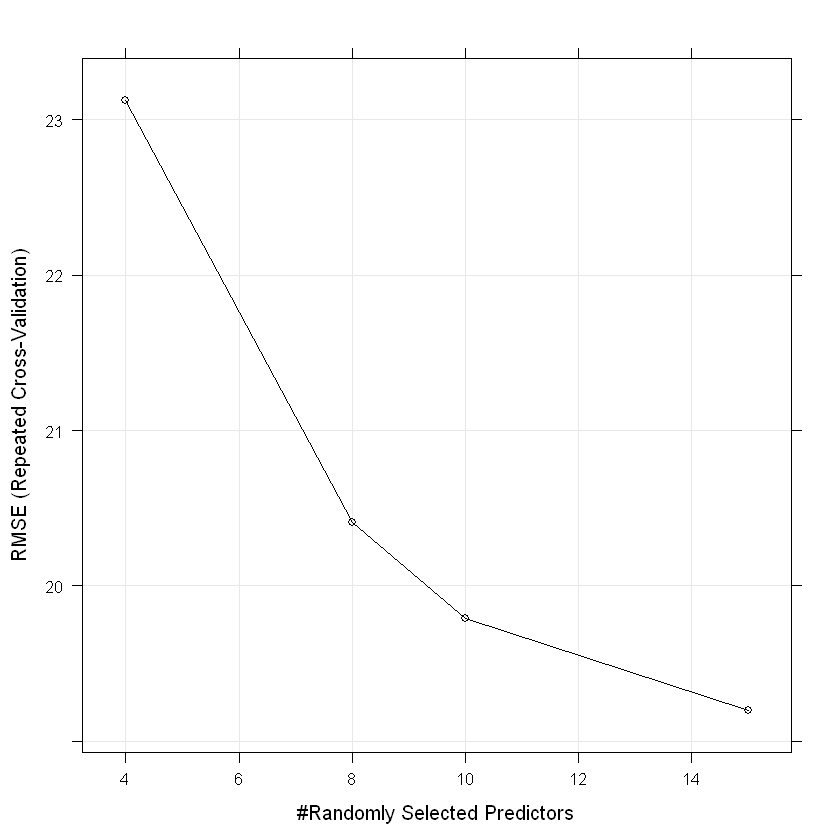

```r
rf_fit
plot(rf_fit)
```

```r
RandomForest_blog=predict(rf_fit,newdata=blog_test)
```

### Performanca Measure

```r
perf_dt("First Data Set for Random Forest", as.numeric(blog_test$target), as.numeric(RandomForest_blog))
```

| name | n | mean | sd | FBias | MAPE | RMSE | MAD | WMAPE |
| --- | --- | --- | --- | --- | --- | --- | --- | --- |
| First Data Set for Random Forest | 1977 | 7.152757 | 16.66787 | -0.2323384 | Inf | 0.2484009 | 5.514749 | 0.7709963 |

## Stochastic Gradient Boosting(SGB)

```r
set.seed(35)
```

```r
blog_train[,X0.0.1:=NULL]
blog_train[,X0.0.2:=NULL]
blog_train[,X0.0.5:=NULL]
blog_train[,X0.0.7:=NULL]
blog_train[,X0.0.8:=NULL]
blog_train[,X0.0.9:=NULL]
blog_train[,X0.0.10:=NULL]
blog_train[,X0.0.11:=NULL]
blog_train[,X0.0.13:=NULL]
blog_train[,X0.0.234:=NULL]

blog_test[,X0.0.1:=NULL]
blog_test[,X0.0.2:=NULL]
blog_test[,X0.0.5:=NULL]
blog_test[,X0.0.7:=NULL]
blog_test[,X0.0.8:=NULL]
blog_test[,X0.0.9:=NULL]
blog_test[,X0.0.10:=NULL]
blog_test[,X0.0.11:=NULL]
blog_test[,X0.0.13:=NULL]
blog_test[,X0.0.234:=NULL]
```

```
Stochastic Gradient Boosting

8023 samples
 270 predictor

No pre-processing
Resampling: Cross-Validated (10 fold, repeated 1 times)
Summary of sample sizes: 7222, 7220, 7221, 7220, 7220, 7221, ...
Resampling results across tuning parameters:

  shrinkage  interaction.depth  n.trees  RMSE      Rsquared   MAE
  0.1        1                   25      23.51668  0.2849392  9.506556
  0.1        1                   50      22.80351  0.3032841  8.832547
  0.1        1                   75      22.65047  0.3098092  8.775545
  0.1        1                  100      22.63235  0.3104455  8.889400
  0.1        1                  125      22.61024  0.3117079  8.963804
  0.1        3                   25      21.73289  0.3743305  8.388996
  0.1        3                   50      21.29655  0.3899361  8.003750
  0.1        3                   75      21.22808  0.3937943  7.952887
  0.1        3                  100      21.24836  0.3933181  7.957694
  0.1        3                  125      21.13266  0.3985761  7.919171
  0.1        5                   25      21.26734  0.3942678  8.123113
  0.1        5                   50      20.84592  0.4144188  7.840904
  0.1        5                   75      20.78450  0.4185088  7.786754
  0.1        5                  100      20.73843  0.4216444  7.728035
  0.1        5                  125      20.73801  0.4216841  7.708666
  0.3        1                   25      22.75991  0.3033429  8.904484
  0.3        1                   50      22.65425  0.3091259  9.147864
  0.3        1                   75      22.68049  0.3069109  9.257940
  0.3        1                  100      22.77801  0.3042892  9.366215
  0.3        1                  125      22.77007  0.3031796  9.357287
  0.3        3                   25      21.28949  0.3898692  8.032260
  0.3        3                   50      21.25482  0.3920144  7.976828
  0.3        3                   75      21.22668  0.3973066  8.035365
  0.3        3                  100      21.21552  0.3991163  8.059988
  0.3        3                  125      21.10101  0.4055901  8.013156
  0.3        5                   25      21.10461  0.4021767  7.928543
  0.3        5                   50      21.16008  0.4007089  8.003955
  0.3        5                   75      21.25418  0.3979742  8.047919
  0.3        5                  100      21.19502  0.4028374  8.094952
  0.3        5                  125      21.09334  0.4105282  8.136736
  0.5        1                   25      22.76220  0.3027179  9.365923
  0.5        1                   50      22.73948  0.3035954  9.498467
  0.5        1                   75      22.74929  0.3061885  9.567049
  0.5        1                  100      22.91499  0.2977383  9.577378
  0.5        1                  125      22.78342  0.3039703  9.621800
  0.5        3                   25      21.71309  0.3709643  8.255165
  0.5        3                   50      21.79729  0.3697018  8.442765
  0.5        3                   75      21.73295  0.3773797  8.484411
  0.5        3                  100      21.77754  0.3752535  8.594138
  0.5        3                  125      21.88520  0.3726704  8.727003
  0.5        5                   25      21.70753  0.3759009  8.311945
  0.5        5                   50      21.75311  0.3799195  8.508803
  0.5        5                   75      21.67053  0.3851793  8.716010
  0.5        5                  100      21.83928  0.3843722  8.839735
  0.5        5                  125      21.88843  0.3866019  8.871959

Tuning parameter 'n.minobsinnode' was held constant at a value of 20
RMSE was used to select the optimal model using the smallest value.
The final values used for the model were n.trees = 125, interaction.depth =
 5, shrinkage = 0.1 and n.minobsinnode = 20.
```

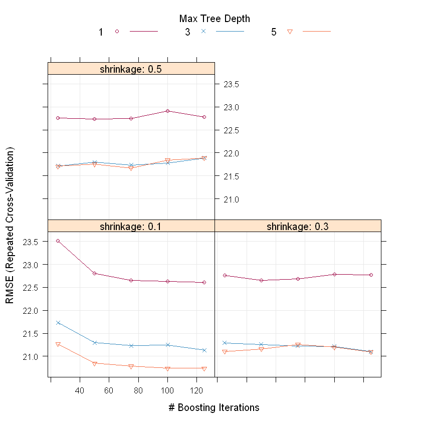

```r
gbmGrid=expand.grid(interaction.depth = c(1, 3, 5),
                        n.trees = (1:5)*25,
                        shrinkage = c(0.1, 0.3, 0.5),
                        n.minobsinnode = 20)


gbm_fit=train(target ~ ., data = blog_train,
                 method = "gbm",
                 trControl = fitControl,
                 tuneGrid = gbmGrid,
                 verbose=F)

gbm_fit
plot(gbm_fit)
```

```r
predicted_blog_sgb=predict(gbm_fit,blog_test)
```

### Performanca Measure

```r
perf_dt("First Data Set for Stochastic Gradient Boosting",as.numeric(blog_test$target), as.numeric(predicted_blog_sgb))
```

| name | n | mean | sd | FBias | MAPE | RMSE | MAD | WMAPE |
| --- | --- | --- | --- | --- | --- | --- | --- | --- |
| First Data Set for Stochastic Gradient Boosting | 1977 | 7.152757 | 16.66787 | -0.1954518 | Inf | 0.3035566 | 6.246727 | 0.8733313 |

# General Result for 4 Method for Blog Comment Results

```r
perf_dt("Blog Comment Set for Lasso Function with min lambda and mse objective", as.numeric(blog_test$target), prediction_pra_mse_blog_1se)
perf_dt("Decision Tree with CV for Blog Comment Dataset",blog_test$target,as.numeric(predicted_blog_dt))
perf_dt("First Data Set for Random Forest", as.numeric(blog_test$target), as.numeric(RandomForest_blog))
perf_dt("First Data Set for Stochastic Gradient Boosting", as.numeric(blog_test$target), as.numeric(predicted_blog_sgb) )
```

| name | n | mean | sd | FBias | MAPE | RMSE | MAD | WMAPE |
| --- | --- | --- | --- | --- | --- | --- | --- | --- |
| Blog Comment Set for Lasso Function with min lambda and mse objective | 1977 | 7.152757 | 16.66787 | -0.2301968 | Inf | 0.3298626 | 8.726155 | 1.219971 |

| name | n | mean | sd | FBias | MAPE | RMSE | MAD | WMAPE |
| --- | --- | --- | --- | --- | --- | --- | --- | --- |
| Decision Tree with CV for Blog Comment Dataset | 1977 | 7.152757 | 16.66787 | -0.211185 | NaN | 0.3807407 | 6.082319 | 0.8503462 |

| name | n | mean | sd | FBias | MAPE | RMSE | MAD | WMAPE |
| --- | --- | --- | --- | --- | --- | --- | --- | --- |
| First Data Set for Random Forest | 1977 | 7.152757 | 16.66787 | -0.2323384 | Inf | 0.2484009 | 5.514749 | 0.7709963 |

| name | n | mean | sd | FBias | MAPE | RMSE | MAD | WMAPE |
| --- | --- | --- | --- | --- | --- | --- | --- | --- |
| First Data Set for Stochastic Gradient Boosting | 1977 | 7.152757 | 16.66787 | -0.1954518 | Inf | 0.3035566 | 6.246727 | 0.8733313 |

# Conclusion of Models

## Linear Regression with Penalty

```r
lm_model
```

```
glmnet

8023 samples
 280 predictor

No pre-processing
Resampling: Cross-Validated (10 fold, repeated 1 times)
Summary of sample sizes: 7221, 7220, 7220, 7220, 7222, 7220, ...
Resampling results across tuning parameters:

  lambda    RMSE      Rsquared   MAE
  2.441102  24.42847  0.2050926   9.869664
  3.226993  24.61889  0.2009448  10.022668
  4.681814  25.07599  0.1863053  10.510031

Tuning parameter 'alpha' was held constant at a value of 1
RMSE was used to select the optimal model using the smallest value.
The final values used for the model were alpha = 1 and lambda = 2.441102.
```

### Best Model for Penalized Regression Approach

RMSE will be the objective parameter for evaluation of the model. In this perpective, **lambda 2.441102(lambda.min) and MAE Penalty type** is the best tuned parameter for this model for Blog Comment Dataset.

```r
print(paste("The Smallest RMSE value in Penalized Regression Approach:",lm_model$results$RMSE[which.min(lm_model$results$RMSE)]))
```

```
[1] "The Smallest RMSE value in Penalized Regression Approach: 24.4284740530075"
```

## Decision Tree

```r
tr_last
```

```
CART

8023 samples
 280 predictor

No pre-processing
Resampling: Cross-Validated (10 fold, repeated 1 times)
Summary of sample sizes: 7220, 7220, 7221, 7222, 7221, 7220, ...
Resampling results across tuning parameters:

  cp    RMSE      Rsquared   MAE
  0.00  22.57559  0.3897072   7.384471
  0.01  23.31100  0.2881720   8.693458
  0.02  23.59941  0.2619470   9.289978
  0.03  23.57051  0.2572654   9.434858
  0.04  24.22841  0.2119279   9.718694
  0.05  24.51101  0.1872444   9.984797
  0.06  24.51033  0.1872444   9.990837
  0.07  25.27038  0.1352021  10.349000
  0.08  25.27885  0.1329492  10.415419
  0.09  25.27885  0.1329492  10.415419
  0.10  25.27885  0.1329492  10.415419

RMSE was used to select the optimal model using the smallest value.
The final value used for the model was cp = 0.
```

### Best Model for Decision Tree

```r
print(paste("The Smallest RMSE value in Decision Tree:",tr_last$results$RMSE[which.min(tr_last$results$RMSE)]))
```

```
[1] "The Smallest RMSE value in Decision Tree: 22.5755890810299"
```

## Random Forest

```r
rf_fit
```

```
Random Forest

8023 samples
 280 predictor

No pre-processing
Resampling: Cross-Validated (10 fold, repeated 1 times)
Summary of sample sizes: 7220, 7221, 7220, 7221, 7221, 7221, ...
Resampling results across tuning parameters:

  mtry  RMSE      Rsquared   MAE
   4    23.12233  0.3410507  9.550554
   8    20.40609  0.4818724  7.921203
  10    19.78936  0.5023333  7.523441
  15    19.20015  0.5178478  6.988483

Tuning parameter 'splitrule' was held constant at a value of variance

Tuning parameter 'min.node.size' was held constant at a value of 5
RMSE was used to select the optimal model using the smallest value.
The final values used for the model were mtry = 15, splitrule = variance
 and min.node.size = 5.
```

### Best Model for Random Forest

RMSE will be the objective parameter for evaluation of the model. In this perpective, **mtry=15** is the best tuned parameter for this model for Blog Comment Dataset.

```r
print(paste("The Smallest RMSE value in Random Forest:",rf_fit$results$RMSE[which.min(rf_fit$results$RMSE)]))
```

```
[1] "The Smallest RMSE value in Random Forest: 19.2001454757668"
```

## Stochastic Gradient Boosting

```r
gbm_fit
```

```
Stochastic Gradient Boosting

8023 samples
 270 predictor

No pre-processing
Resampling: Cross-Validated (10 fold, repeated 1 times)
Summary of sample sizes: 7222, 7220, 7221, 7220, 7220, 7221, ...
Resampling results across tuning parameters:

  shrinkage  interaction.depth  n.trees  RMSE      Rsquared   MAE
  0.1        1                   25      23.51668  0.2849392  9.506556
  0.1        1                   50      22.80351  0.3032841  8.832547
  0.1        1                   75      22.65047  0.3098092  8.775545
  0.1        1                  100      22.63235  0.3104455  8.889400
  0.1        1                  125      22.61024  0.3117079  8.963804
  0.1        3                   25      21.73289  0.3743305  8.388996
  0.1        3                   50      21.29655  0.3899361  8.003750
  0.1        3                   75      21.22808  0.3937943  7.952887
  0.1        3                  100      21.24836  0.3933181  7.957694
  0.1        3                  125      21.13266  0.3985761  7.919171
  0.1        5                   25      21.26734  0.3942678  8.123113
  0.1        5                   50      20.84592  0.4144188  7.840904
  0.1        5                   75      20.78450  0.4185088  7.786754
  0.1        5                  100      20.73843  0.4216444  7.728035
  0.1        5                  125      20.73801  0.4216841  7.708666
  0.3        1                   25      22.75991  0.3033429  8.904484
  0.3        1                   50      22.65425  0.3091259  9.147864
  0.3        1                   75      22.68049  0.3069109  9.257940
  0.3        1                  100      22.77801  0.3042892  9.366215
  0.3        1                  125      22.77007  0.3031796  9.357287
  0.3        3                   25      21.28949  0.3898692  8.032260
  0.3        3                   50      21.25482  0.3920144  7.976828
  0.3        3                   75      21.22668  0.3973066  8.035365
  0.3        3                  100      21.21552  0.3991163  8.059988
  0.3        3                  125      21.10101  0.4055901  8.013156
  0.3        5                   25      21.10461  0.4021767  7.928543
  0.3        5                   50      21.16008  0.4007089  8.003955
  0.3        5                   75      21.25418  0.3979742  8.047919
  0.3        5                  100      21.19502  0.4028374  8.094952
  0.3        5                  125      21.09334  0.4105282  8.136736
  0.5        1                   25      22.76220  0.3027179  9.365923
  0.5        1                   50      22.73948  0.3035954  9.498467
  0.5        1                   75      22.74929  0.3061885  9.567049
  0.5        1                  100      22.91499  0.2977383  9.577378
  0.5        1                  125      22.78342  0.3039703  9.621800
  0.5        3                   25      21.71309  0.3709643  8.255165
  0.5        3                   50      21.79729  0.3697018  8.442765
  0.5        3                   75      21.73295  0.3773797  8.484411
  0.5        3                  100      21.77754  0.3752535  8.594138
  0.5        3                  125      21.88520  0.3726704  8.727003
  0.5        5                   25      21.70753  0.3759009  8.311945
  0.5        5                   50      21.75311  0.3799195  8.508803
  0.5        5                   75      21.67053  0.3851793  8.716010
  0.5        5                  100      21.83928  0.3843722  8.839735
  0.5        5                  125      21.88843  0.3866019  8.871959

Tuning parameter 'n.minobsinnode' was held constant at a value of 20
RMSE was used to select the optimal model using the smallest value.
The final values used for the model were n.trees = 125, interaction.depth =
 5, shrinkage = 0.1 and n.minobsinnode = 20.
```

### Best Model for Stochastic Gradient Boosting

RMSE will be the objective parameter for evaluation of the model. In this perpective, **n.trees = 125 interaction.depth = 5, shrinkage = 0.1 and n.minobsinnode = 20** is the best tuned parameter for this model for Number of Blog Dataset.

```r
print(paste("The Smallest RMSE value in Stochastic Gradient Boosting:",gbm_fit$results$RMSE[which.min(gbm_fit$results$RMSE)]))
```

```
[1] "The Smallest RMSE value in Stochastic Gradient Boosting: 20.7380054790217"
```

# Comparision of Results in Training and Test Dataset

```r
train=list("Linear Regression with Lasso Results"=lm_model$results$RMSE[which.min(lm_model$results$RMSE)],
            "Decision Tree Results"=    tr_last$results$RMSE[which.min(tr_last$results$RMSE)],
            "Random Forest Results"=    rf_fit$results$RMSE[which.min(rf_fit$results$RMSE)],
            "Result Stochastic Gradient Boosting Results"=    gbm_fit$results$RMSE[which.min(gbm_fit$results$RMSE)])
```

## RMSE in The Train Dataset

```r
t(train)
```

| Linear Regression with Lasso Results | Decision Tree Results | Random Forest Results | Result Stochastic Gradient Boosting Results |
| --- | --- | --- | --- |
| 24.42847 | 22.57559 | 19.20015 | 20.73801 |

```r
perf_dt("Blog Comment Data Set for Lasso Function with min lambda and mse objective", as.numeric(blog_test$target), prediction_pra_mse_blog_1se)
perf_dt("Decision Tree with CV for Blog Comment Dataset",blog_test$target,as.numeric(predicted_blog_dt))
perf_dt("First Data Set for Random Forest", as.numeric(blog_test$target), as.numeric(RandomForest_blog))
perf_dt("First Data Set for Stochastic Gradient Boosting", as.numeric(blog_test$target), as.numeric(predicted_blog_sgb) )
```

| name | n | mean | sd | FBias | MAPE | RMSE | MAD | WMAPE |
| --- | --- | --- | --- | --- | --- | --- | --- | --- |
| Blog Comment Data Set for Lasso Function with min lambda and mse objective | 1977 | 7.152757 | 16.66787 | -0.2301968 | Inf | 0.3298626 | 8.726155 | 1.219971 |

| name | n | mean | sd | FBias | MAPE | RMSE | MAD | WMAPE |
| --- | --- | --- | --- | --- | --- | --- | --- | --- |
| Decision Tree with CV for Blog Comment Dataset | 1977 | 7.152757 | 16.66787 | -0.211185 | NaN | 0.3807407 | 6.082319 | 0.8503462 |

| name | n | mean | sd | FBias | MAPE | RMSE | MAD | WMAPE |
| --- | --- | --- | --- | --- | --- | --- | --- | --- |
| First Data Set for Random Forest | 1977 | 7.152757 | 16.66787 | -0.2323384 | Inf | 0.2484009 | 5.514749 | 0.7709963 |

| name | n | mean | sd | FBias | MAPE | RMSE | MAD | WMAPE |
| --- | --- | --- | --- | --- | --- | --- | --- | --- |
| First Data Set for Stochastic Gradient Boosting | 1977 | 7.152757 | 16.66787 | -0.1954518 | Inf | 0.3035566 | 6.246727 | 0.8733313 |